# yrnd_functions

```r
library(yrnd)
```

## yrnd

The package ‘“yrnd”’ estimates a parametric form of the Risk Neutral Density (RND) of the price of fixed-income futures such as Short Term Interest Rates futures and government bond futures, using options written on those futures. The RND is estimated at options’ maturity. The package also provides with the distribution of STIR rates futures and government bond yields themselves at options’ maturity, using the RND of respectively the futures price of the STIR futures and the bond futures. It provides with some statistics of the distribution as well as a density and a cumulative density plot. Also, it provides with the probability attached to each bond in the delivery basket of a government bond futures contract to be the cheapest at maturity of the futures.

## stir_future_price provides with the risk neutral density of the STIR futures price, using options on the STIR futures

```r
stir_future_price( c(1.44500, 1.32000, 1.19750, 1.07500, 0.95750,
0.84250, 0.78750, 0.73250, 0.68000, 0.62750, 0.57750, 0.53000, 0.48500,
0.44000, 0.39750, 0.35750, 0.32000, 0.28500, 0.25250, 0.22250, 0.19500,
0.17000, 0.14750, 0.12750, 0.10750, 0.09250, 0.07750, 0.06500, 0.05500,
0.04500, 0.03750, 0.03000, 0.02500, 0.02000, 0.01500, 0.01250, 0.01000,
0.00750, 0.00500, 0.00500, 0.00250, 0.00250, 0.00250, 0.00250,
rep(0.00024, 47)),
c(seq(93.25, 93.875, 0.125),  seq(93.9375, 98.8125, 0.0625),
seq(98.875, 99.5, 0.125)),
c(0.0025, 0.0050, 0.0075, 0.0125, 0.0175, 0.0300, 0.0350, 0.0425, 0.0525,
0.0625, 0.0750, 0.0900, 0.1050, 0.1225, 0.1425, 0.1650, 0.1900, 0.2175,
0.2450, 0.2775, 0.3125, 0.3500, 0.3875, 0.4300, 0.4725, 0.5175, 0.5675,
0.6150, 0.6675, 0.7200, 0.7750, 0.8300, 0.8850, 0.9425, 1.0025, 1.0625,
1.1225, 1.1825, 1.2425, 1.3050, 1.3675, 1.4300, 1.4925, 1.5550, 1.6175,
1.6800, 1.7425, 1.8050, 1.8675, 1.9300, 1.9925, 2.0550, 2.1175, 2.1800,
2.2425, 2.3050, 2.3675, 2.4300, 2.4925, 2.5550, 2.6175, 2.6800, 2.7425,
2.8050, 2.8675, 2.9300, 2.9925, 3.0550, 3.1175, 3.1800, 3.2425, 3.3050,
3.3675, 3.4300, 3.4925, 3.5550, 3.6175, 3.6800, 3.7425, 3.8050, 3.8675,
3.9300, 3.9925, 4.0550, 4.1175, 4.1800, 4.3050, 4.4300, 4.5550, 4.6800,
4.8050),
c(seq(93.25, 93.875, 0.125),  seq(93.9375, 98.8125, 0.0625),
seq(98.875, 99.5, 0.125)),
2,
0.0537,
1,
3,
94.7,
as.Date("2024-02-29"),
as.Date("2024-02-25"),
as.Date("2023-12-18"),
"fed_fund_rate",
"USD")
```

```
#> $params
#>             [,1]
#> [1,] 4.554654116
#> [2,] 4.547358544
#> [3,] 0.005305166
#> [4,] 0.005553883
#> [5,] 0.450093499
#> attr(,"names")
#> [1] "m1"  "m2"  "s1"  "s2"  "pi1"
#>
#> $domain
#>     [1]  90.48038  90.48138  90.48238  90.48338  90.48438  90.48538  90.48638
#>     [8]  90.48738  90.48838  90.48938  90.49038  90.49138  90.49238  90.49338
#>    [15]  90.49438  90.49538  90.49638  90.49738  90.49838  90.49938  90.50038
#>    [22]  90.50138  90.50238  90.50338  90.50438  90.50538  90.50638  90.50738
```

[output cut: 5496 more lines]

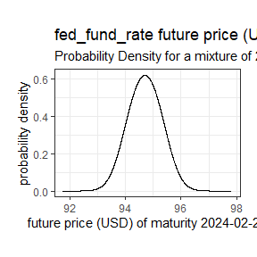

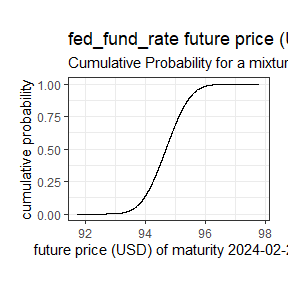

## stir_rate provides with the risk neutral density of the STIR rate implicit in the STIR futures price, using options on the STIR futures

```r
stir_rate( c(1.44500, 1.32000, 1.19750, 1.07500, 0.95750,
0.84250, 0.78750, 0.73250, 0.68000, 0.62750, 0.57750, 0.53000, 0.48500,
0.44000, 0.39750, 0.35750, 0.32000, 0.28500, 0.25250, 0.22250, 0.19500,
0.17000, 0.14750, 0.12750, 0.10750, 0.09250, 0.07750, 0.06500, 0.05500,
0.04500, 0.03750, 0.03000, 0.02500, 0.02000, 0.01500, 0.01250, 0.01000,
0.00750, 0.00500, 0.00500, 0.00250, 0.00250, 0.00250, 0.00250,
rep(0.00024, 47)),
c(seq(93.25, 93.875, 0.125),  seq(93.9375, 98.8125, 0.0625),
seq(98.875, 99.5, 0.125)),
c(0.0025, 0.0050, 0.0075, 0.0125, 0.0175, 0.0300, 0.0350, 0.0425,
0.0525, 0.0625, 0.0750, 0.0900, 0.1050, 0.1225, 0.1425, 0.1650, 0.1900,
0.2175, 0.2450, 0.2775, 0.3125, 0.3500, 0.3875, 0.4300, 0.4725, 0.5175,
0.5675, 0.6150, 0.6675, 0.7200, 0.7750, 0.8300, 0.8850, 0.9425, 1.0025,
1.0625, 1.1225, 1.1825, 1.2425, 1.3050, 1.3675, 1.4300, 1.4925, 1.5550,
1.6175, 1.6800, 1.7425, 1.8050, 1.8675, 1.9300, 1.9925, 2.0550, 2.1175,
2.1800, 2.2425, 2.3050, 2.3675, 2.4300, 2.4925, 2.5550, 2.6175, 2.6800,
2.7425, 2.8050, 2.8675, 2.9300, 2.9925, 3.0550, 3.1175, 3.1800, 3.2425,
3.3050, 3.3675, 3.4300, 3.4925, 3.5550, 3.6175, 3.6800, 3.7425, 3.8050,
3.8675, 3.9300, 3.9925, 4.0550, 4.1175, 4.1800, 4.3050, 4.4300, 4.5550,
4.6800, 4.8050),
c(seq(93.25, 93.875, 0.125),  seq(93.9375, 98.8125, 0.0625),
seq(98.875, 99.5, 0.125)),
2,
0.0537,
1,
3,
94.7,
as.Date("2024-02-29"),
as.Date("2024-02-25"),
as.Date("2023-12-18"),
"fed_fund_rate",
"USD")
```

```
#> $domain
#>     [1] -0.49438175 -0.49338175 -0.49238175 -0.49138175 -0.49038175 -0.48938175
#>     [7] -0.48838175 -0.48738175 -0.48638175 -0.48538175 -0.48438175 -0.48338175
#>    [13] -0.48238175 -0.48138175 -0.48038175 -0.47938175 -0.47838175 -0.47738175
#>    [19] -0.47638175 -0.47538175 -0.47438175 -0.47338175 -0.47238175 -0.47138175
#>    [25] -0.47038175 -0.46938175 -0.46838175 -0.46738175 -0.46638175 -0.46538175
#>    [31] -0.46438175 -0.46338175 -0.46238175 -0.46138175 -0.46038175 -0.45938175
#>    [37] -0.45838175 -0.45738175 -0.45638175 -0.45538175 -0.45438175 -0.45338175
#>    [43] -0.45238175 -0.45138175 -0.45038175 -0.44938175 -0.44838175 -0.44738175
#>    [49] -0.44638175 -0.44538175 -0.44438175 -0.44338175 -0.44238175 -0.44138175
#>    [55] -0.44038175 -0.43938175 -0.43838175 -0.43738175 -0.43638175 -0.43538175
#>    [61] -0.43438175 -0.43338175 -0.43238175 -0.43138175 -0.43038175 -0.42938175
#>    [67] -0.42838175 -0.42738175 -0.42638175 -0.42538175 -0.42438175 -0.42338175
#>    [73] -0.42238175 -0.42138175 -0.42038175 -0.41938175 -0.41838175 -0.41738175
#>    [79] -0.41638175 -0.41538175 -0.41438175 -0.41338175 -0.41238175 -0.41138175
```

[output cut: 5684 more lines]

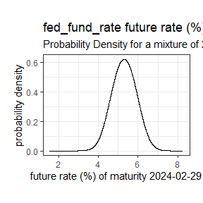

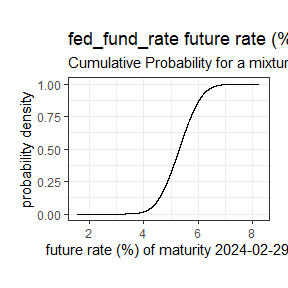

## bond_future_price provides with the risk neutral density of the government bond futures price, using options on the government bond futures

```r
bond_future_price(c(10.39,9.92,9.46,9.00,8.55,8.10,7.66,7.23,
6.81,6.39,5.98,5.58,5.20,4.82,4.46,4.10,3.76,3.44,3.13,2.83,2.56,
2.29,2.05,1.82,1.61,1.42,1.25,1.09,0.95,0.82,0.71,0.61,0.53,0.45,
0.38,0.33,0.28,0.23,0.20,0.17,0.14,0.12,0.10,0.08),
seq(106, 127.5, 0.5),
c(0.22,0.25,0.29,0.33,0.38,0.43,0.49,0.56,0.64,0.72,0.81,0.91,
1.03,1.15,1.29, 1.43,1.59,1.77,1.96,2.16,2.39,2.62,2.88,3.15,
3.44,3.75,4.08, 4.42,4.78,5.15,5.54,5.94,6.36,6.78,7.21,7.66,
8.11,8.56,9.03, 9.50,9.97,10.45,10.93,11.41),
seq(106, 127.5, 0.5),
2,
0.0344,
1,
3,
as.Date("2033-11-01"),
116.17,
as.Date("2024-12-10"),
as.Date("2024-11-22"),
as.Date("2024-06-14"),
"Italian",
"EUR")
```

```
#> $params
#>            [,1]
#> [1,] 4.73733557
#> [2,] 4.77141588
#> [3,] 0.06384429
#> [4,] 0.03548331
#> [5,] 0.52406642
#> attr(,"names")
#> [1] "m1"  "m2"  "s1"  "s2"  "pi1"
#>
#> $domain
#>     [1]  86.69814  86.69914  86.70014  86.70114  86.70214  86.70314  86.70414
#>     [8]  86.70514  86.70614  86.70714  86.70814  86.70914  86.71014  86.71114
#>    [15]  86.71214  86.71314  86.71414  86.71514  86.71614  86.71714  86.71814
#>    [22]  86.71914  86.72014  86.72114  86.72214  86.72314  86.72414  86.72514
```

[output cut: 34137 more lines]

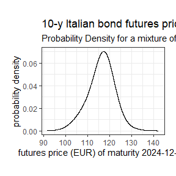

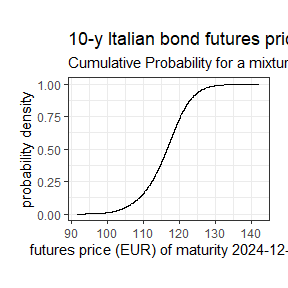

## ctd_bond_yield provides with the risk neutral density of the yield to maturity of the Cheapest-to-Deliver Bond in a futures contract, using options on the government bond futures

```r
ctd_bond_yield(c(10.39,9.92,9.46,9.00,8.55,8.10,7.66,7.23,
6.81,6.39,5.98,5.58,5.20,4.82,4.46,4.10,3.76,3.44,3.13,2.83,2.56,
2.29,2.05,1.82,1.61,1.42,1.25,1.09,0.95,0.82,0.71,0.61,0.53,0.45,
0.38,0.33,0.28,0.23,0.20,0.17,0.14,0.12,0.10,0.08),
seq(106, 127.5, 0.5),
c(0.22,0.25,0.29,0.33,0.38,0.43,0.49,0.56,0.64,0.72,0.81,0.91,
1.03,1.15,1.29, 1.43,1.59,1.77,1.96,2.16,2.39,2.62,2.88,3.15,
3.44,3.75,4.08, 4.42,4.78,5.15,5.54,5.94,6.36,6.78,7.21,7.66,
8.11,8.56,9.03, 9.50,9.97,10.45,10.93,11.41),
seq(106, 127.5, 0.5),
2,
0.0344,
0.035,
1,
3,
0.893,
0.0435,
as.Date("2033-11-01"),
2,
100,
2,
116.17,
as.Date("2024-12-10"),
as.Date("2024-11-22"),
as.Date("2024-06-14"),
"Italian",
"EUR")
```

```
#> $domain
#>     [1] 0.005404898 0.005405766 0.005406635 0.005407503 0.005408372 0.005409240
#>     [7] 0.005410109 0.005410978 0.005411846 0.005412715 0.005413583 0.005414452
#>    [13] 0.005415320 0.005416189 0.005417058 0.005417926 0.005418795 0.005419663
#>    [19] 0.005420532 0.005421401 0.005422269 0.005423138 0.005424006 0.005424875
#>    [25] 0.005425744 0.005426612 0.005427481 0.005428350 0.005429218 0.005430087
#>    [31] 0.005430956 0.005431825 0.005432693 0.005433562 0.005434431 0.005435299
#>    [37] 0.005436168 0.005437037 0.005437906 0.005438774 0.005439643 0.005440512
#>    [43] 0.005441381 0.005442249 0.005443118 0.005443987 0.005444856 0.005445725
#>    [49] 0.005446593 0.005447462 0.005448331 0.005449200 0.005450069 0.005450938
#>    [55] 0.005451806 0.005452675 0.005453544 0.005454413 0.005455282 0.005456151
#>    [61] 0.005457020 0.005457889 0.005458757 0.005459626 0.005460495 0.005461364
#>    [67] 0.005462233 0.005463102 0.005463971 0.005464840 0.005465709 0.005466578
#>    [73] 0.005467447 0.005468316 0.005469185 0.005470054 0.005470923 0.005471792
#>    [79] 0.005472661 0.005473530 0.005474399 0.005475268 0.005476137 0.005477006
```

[output cut: 35598 more lines]

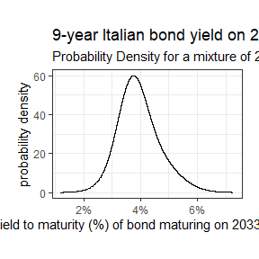

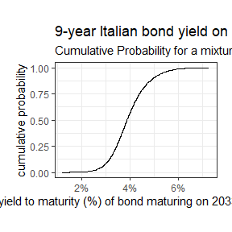

## proba_ctd provides, for each bond in the delivery basket of a government bond futures contact, its probability to be the cheapest to deliver bond at futures maturity.

```r
proba_ctd( c(24.10, 23.10, 22.12, 21.12, 20.12, 19.14, 18.14, 17.16, 16.18, 15.20,
14.22, 13.24, 12.28, 11.32, 10.36, 9.44, 8.50, 7.60, 6.72, 5.86, 5.04, 4.28,
3.56, 2.88, 2.30, 1.78,  1.36, 1.02, 0.76, 0.56, 0.42, 0.30, 0.22, 0.18, 0.14,
0.10,  0.08, 0.06, 0.06, 0.04, 0.04, 0.02, 0.02, 0.02, 0.02, 0.02, 0.02),
seq(85, 131),
c(0.02,  0.02, 0.02, 0.02, 0.02, 0.04, 0.04, 0.06, 0.08, 0.10, 0.12, 0.14, 0.18, 0.22,
0.26, 0.34,  0.40, 0.50, 0.62, 0.76, 0.94, 1.18, 1.46, 1.78, 2.20, 2.68, 3.26, 3.92,
4.66,  5.46, 6.32, 7.20, 8.12, 9.08, 10.04, 11.00, 11.98, 12.96, 13.96, 14.94, 15.94,
16.92, 17.92, 18.92, 19.92, 20.92, 21.92),
seq(85, 131),
2,
0.0187,
1,
3,
as.Date("2054-08-15"),
109.1,
as.Date("2026-09-08"),
as.Date("2026-08-21"),
as.Date("2026-05-28"),
c("DE0001102572", "DE0001102614", "DE0001030757", "DE000BU2D004", "DE000BU2D012"),
c(0.000, 0.018, 0.018, 0.025, 0.029),
rep(1, 5),
as.Date(c("2052-08-15", "2053-08-15", "2053-08-15", "2054-08-15", "2056-08-15")),
100,
c(0.361698, 0.641260, 0.641260, 0.750372, 0.809987),
c(0.03500, 0.03507, 0.03492, 0.03510, 0.03514),
2)
```

```
#>           ISIN proba_ctd_matu
#> 1 DE000BU2D004          0.673
#> 2 DE000BU2D012          0.261
#> 3 DE0001102572          0.066
#> 4 DE0001102614          0.000
#> 5 DE0001030757          0.000
```